# Analysis of my Google Drive files (WIP)

Dave Hurst

```r
library(tidyverse)
library(stringr)
library(googledrive)
library(googlesheets)
library(lubridate)
library(data.tree)
library(cowplot)
library(tictoc)
theme_set(theme_gray())
```

```r
cached = TRUE
cache_all <- 'all.rds'
if (file.exists(cache_all) && cached) {
    files <- readRDS(cache_all)
} else {
    tic()
    files <- drive_find()
    saveRDS(files, cache_all)
    toc()
}
```

Let’s look at both count and size accumulation over time. Note that file size is only counted for files that are stored in native format (i.e. not Google Docs)

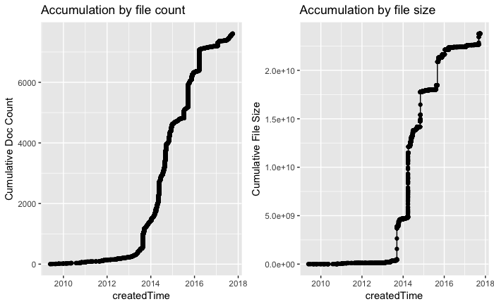

```r
files <- files %>% googledrive:::promote('createdTime')
plot_by_count <- files %>%
    mutate(createdTime = ymd_hms(createdTime),
           `Cumulative Doc Count` = row_number(createdTime)) %>%
    ggplot(aes(createdTime, `Cumulative Doc Count`, group=1)) + geom_line() + geom_point() +
    ggtitle('Accumulation by file count')
files <- files %>% googledrive:::promote('quotaBytesUsed') %>%
    mutate(q_size = as.numeric(quotaBytesUsed))
total_size <- sum(files$q_size)
plot_by_size <- files %>%
    arrange(createdTime) %>%
    mutate (createdTime = ymd_hms(createdTime),
            `Cumulative File Size` = cumsum(q_size)) %>%
    ggplot(aes(createdTime, `Cumulative File Size`, group=1)) + geom_line() + geom_point() +
    ggtitle('Accumulation by file size')
plot_grid(plot_by_count, plot_by_size)
```

Interesting. There seem to be several days where a lot of files got added to my Drive. I use the Drive desktop app which automatically syncs files from my PC, so maybe I got a little careless about adding files into that folder. It’s also noteworthy that the size explosion and count explosions don’t always occur on the same days, so I’ll need to look at those separately.

Total quota file size is 23.8 GB.

Let’s start with largest files, and see which Drive paths contain them.

```r
fat_files <- files %>%
    arrange(-q_size) %>%
    top_n(10, q_size) %>%
    drive_reveal(what = 'path') %>%
    googledrive:::promote('quotaBytesUsed') %>%  #drive_reveal crunched our dribble
    mutate(sizeGB = round(as.numeric(quotaBytesUsed) / 1e9, 2))
```

```
Items so far:
200 300 400 500 600 700 798
```

```r
fat_files %>% select(path, sizeGB)
```

|  | path | sizeGB |
| --- | --- | --- |
| 1 | ~/NU MSPA/436-TA/TA Posts/demo videos.zip | 2.41 |
| 2 | ~/NU MSPA/453 - Text Analytics/yelp_dataset_challenge_academic_dataset/yelp2b.json | 1.30 |
| 3 | ~/Family Writings and Videos/Harry Hurst Home Movies/VIDEO_TS/VTS_01_1.VOB | 1.07 |
| 4 | ~/Family Writings and Videos/Harry Hurst Home Movies/VIDEO_TS/VTS_01_3.VOB | 1.07 |
| 5 | ~/Family Writings and Videos/Harry Hurst Home Movies/VIDEO_TS/VTS_01_2.VOB | 1.07 |
| 6 | ~/NU MSPA/453 - Text Analytics/yelp_dataset_challenge_academic_dataset/review.json | 1.05 |
| 7 | ~/Career/DS Projects/BikeShare Open Data Challenge/201402_rebalancing_data.csv | 0.62 |
| 8 | ~/Coursera/Data Science Track/Text Analytics Capstone/Coursera-SwiftKey.zip | 0.57 |
| 9 | ~/SKL-Share-tmp/GitLab/3sq_OSA_utils.7z | 0.57 |
| 10 | ~/Temp/weddingcap_rain.7z | 0.48 |

Let’s look at the files by the chronological order they were added and look at the days with the most volume.

```r
fat_days <- files %>% mutate(create_date = createdTime %>% as.Date() %>% as.character()) %>%
    count(create_date, sort = TRUE) %>%
    top_n(10, n)
fat_days
```

| create_date | n |
| --- | --- |
| 2015-09-19 | 702 |
| 2016-03-20 | 684 |
| 2013-08-23 | 418 |
| 2014-05-16 | 336 |
| 2015-07-11 | 244 |
| 2014-09-12 | 167 |
| 2014-05-09 | 160 |
| 2014-11-03 | 98 |
| 2017-01-22 | 92 |
| 2015-11-14 | 83 |

That’s a lot of files. There are probably some folders here that are adding a lot of unnecessary files. Looking up paths can take a long time with the `drive_reveal`. So I want to take a the approach of sampling files added on the days we just identified above. On the assumption that something caused large folders to get added to my drive, this should help me identify those.

```r
set.seed(199)
tic()
fat_day_sample <- files %>%
    mutate(create_date = createdTime %>% as.Date() %>% as.character()) %>%
    semi_join(fat_days) %>%
    group_by(create_date) %>%
    mutate(shuffle = sample(n())) %>%
    top_n(10, shuffle) %>%
    drive_reveal(what = 'path')
```

```
Items so far:
200 300 400 500 600 700 798
```

```r
toc()
```

```
38.12 sec elapsed
```

```r
#prune until any children of a node don't have a minimum threshold
prune_min <- 15 #Clone doesn't have ...
pruneFunction <- function(x) {
    if (isLeaf(x)) return(FALSE)
    if (x$totalCount < prune_min) return(FALSE)
    return( x$totalCount >= prune_min )
}

tree <- as.Node(fat_day_sample, pathName = "path")
pruned <- Clone(tree, pruneFun = pruneFunction)
print(pruned, 'totalCount', pruneMethod = 'dist', limit = NULL)
```

```
                                                   levelName totalCount
1  ~                                                                 23
2   ¦--Coursera                                                       7
3   ¦   °--Data Science Track                                         6
4   ¦       °--Developing Data Products                               5
5   ¦           °--Week2                                              4
6   ¦               °--Quiz2                                          3
7   ¦                   °--libraries                                  2
8   ¦                       °--frameworks                             1
9   ¦--Data Science                                                   5
10  ¦   °--PyImageSearch                                              4
11  ¦       °--Books                                                  3
12  ¦           °--Case Studies, 2nd Edition                          2
13  ¦               °--code                                           1
14  ¦--NU MSPA                                                        9
15  ¦   ¦--ImageAnalytics                                             4
16  ¦   ¦   °--Books                                                  3
17  ¦   ¦       °--Case Studies, 2nd Edition                          2
18  ¦   ¦           °--code                                           1
19  ¦   ¦--453 - Text Analytics                                       1
20  ¦   °--401 Statistics                                             3
21  ¦       °--Elementary Statistics-Triola Text Supplements          2
22  ¦           °--AppB_Data_Sets                                     1
23  °--Tableau Repository                                             1
```

```r
cache_folders <- TRUE
cache_folders_file <- 'folders.rds'
if (cache_folders && file.exists(cache_folders_file)) {
    folders <- readRDS(cache_folders_file)
} else {
    tic()
    folders <- files %>%
        drive_reveal(what = 'mime_type') %>%
        filter(str_detect(mime_type,'apps.folder$')) %>%
        drive_reveal(what = 'path')
    saveRDS(folders, cache_folders_file)
    toc()
}
```

```r
ftree <- as.Node(folders, pathName = "path")
```

```
input string 1 is invalid in this locale
```

```r
ftree$Do(function(x) x$origCount <- x$count)
prune_min <- 10 #Clone doesn't have ...
fpruned <- Clone(ftree, pruneFun = pruneFunction)
print(fpruned, 'totalCount', 'origCount', pruneMethod = 'dist', limit = NULL)
```

```
                                                   levelName totalCount origCount
1  ~                                                                 72        42
2   ¦--Career                                                         2         7
3   ¦   °--2017                                                       1        10
4   ¦--Data Science                                                   5         9
5   ¦   °--PyImageSearch                                              4         1
6   ¦       °--Books                                                  3         2
7   ¦           °--Case Studies, 2nd Edition                          2         2
8   ¦               °--code                                           1         7
9   ¦--Tahoe Condo                                                    1         9
10  ¦--Coursera                                                      29         9
11  ¦   ¦--Big Data Specialization - UCSD                             1         4
12  ¦   ¦--Data Science Track                                        23         9
13  ¦   ¦   ¦--Text Analytics Capstone                                9         3
14  ¦   ¦   ¦   °--SwiftKey                                           8         7
```

[output cut: 58 more lines]

```r
files <- files %>% drive_reveal(what = 'mime_type')
```

```r
file_types <- files %>%
    group_by(mime_type) %>%
    summarize(count = n(),
              total_size = sum(q_size)) %>%
    arrange( -count)
file_types
```

| mime_type | count | total_size |
| --- | --- | --- |
| image/png | 1308 | 248956551 |
| application/octet-stream | 1018 | 3285924025 |
| application/pdf | 1003 | 1106271409 |
| application/vnd.google-apps.folder | 793 | 0 |
| text/csv | 550 | 883381352 |
| application/vnd.google-apps.document | 434 | 0 |
| text/plain | 367 | 504657823 |
| application/x-javascript | 277 | 12832381 |
| image/jpeg | 191 | 132730836 |
| application/x-gzip | 133 | 542808095 |

[output cut: 56 more lines]

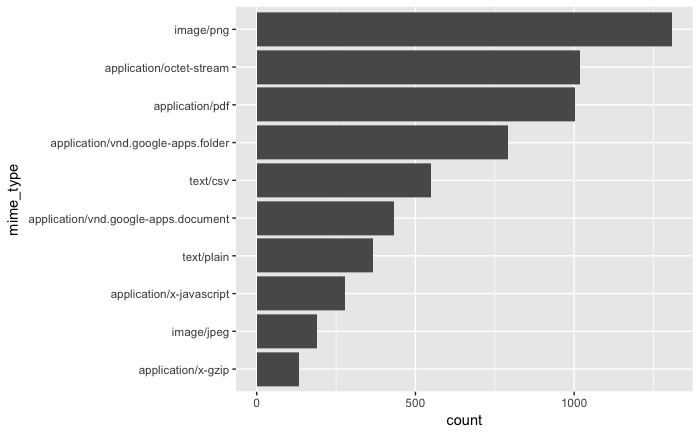

```r
top_ftype <- 10
file_types %>%
    top_n(top_ftype, count) %>%
    mutate(mime_type = reorder(mime_type, count)) %>%
    ggplot(aes(mime_type, count)) + geom_col() + coord_flip()
```

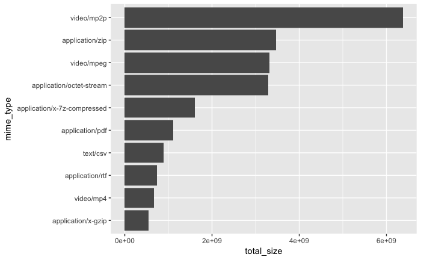

```r
top_ftype <- 10
file_types %>%
    arrange(total_size) %>%
    top_n(top_ftype, total_size) %>%
    mutate(mime_type = reorder(mime_type, total_size)) %>%
    ggplot(aes(mime_type, total_size)) + geom_col() + coord_flip()
```

```r
top_ftype <- 10
top_mime_types <- file_types %>%
    top_n(top_ftype, count) %>%
    select(mime_type) %>% .[[1]]
top_mime_types
```

```
 [1] "image/png"                            "application/octet-stream"
 [3] "application/pdf"                      "application/vnd.google-apps.folder"
 [5] "text/csv"                             "application/vnd.google-apps.document"
 [7] "text/plain"                           "application/x-javascript"
 [9] "image/jpeg"                           "application/x-gzip"
```

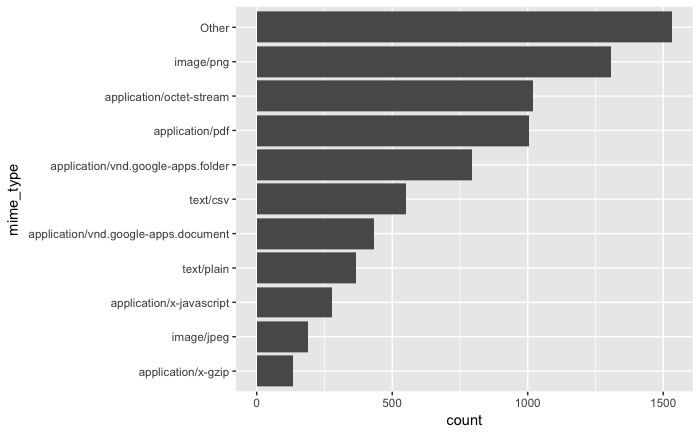

```r
files_otherized <- files %>%
    mutate(mime_type = ifelse(mime_type %in% top_mime_types, mime_type, 'Other'))
files_otherized %>%
    group_by(mime_type) %>%
    summarize(count = n(),
              total_size = sum(q_size)) %>%
    arrange( -count) %>%
    mutate(mime_type = reorder(mime_type, count)) %>%
    ggplot(aes(mime_type, count)) + geom_col() + coord_flip()
```

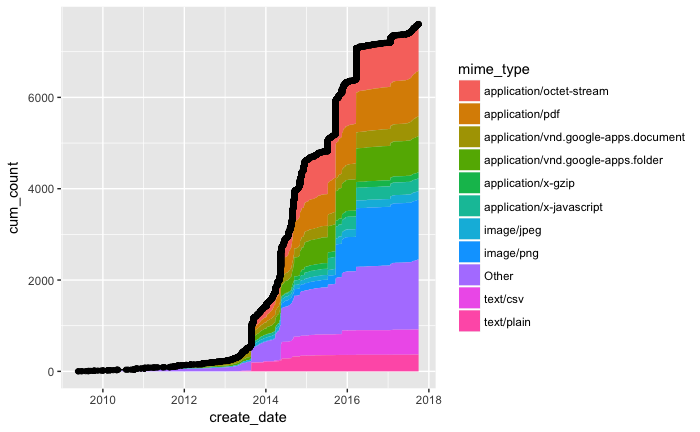

```r
files_cum <- files %>%
    arrange(createdTime) %>%
    mutate(create_date = as.Date(ymd_hms(createdTime)),
           `Cumulative Doc Count` = row_number(createdTime),
           `Cumulative File Size` = cumsum(q_size))
cum_types <- files_otherized %>%
    mutate(create_date = as.Date(ymd_hms(createdTime))) %>%
    #filter(create_date > ymd('2017-01-01')) %>%
    group_by(create_date, mime_type) %>%
    summarize(count = n(),
              total_size = sum(q_size)) %>%
    ungroup() %>%
    complete(create_date, mime_type, fill = list(count = 0, total_size = 0)) %>%
    group_by(mime_type) %>% arrange(create_date) %>%
    mutate( cum_count = cumsum(count),
            cum_size = cumsum(total_size))
cum_all <- cum_types %>% ungroup() %>%
    group_by(create_date) %>%
    summarize( day_count = sum(count),
               day_size = sum(total_size)) %>%
    ungroup() %>% arrange(create_date) %>%
    mutate( count_all = cumsum(day_count),
            size_all = cumsum(day_size))

plot_cum_counts <- cum_types %>%
    ggplot(aes(create_date, cum_count)) +
    geom_area(aes(fill = mime_type)) +
    geom_line(data = files_cum, aes(create_date, `Cumulative Doc Count`, group=1)) +
    geom_point(data = files_cum, aes(create_date, `Cumulative Doc Count`, group=1))
plot_cum_counts
```

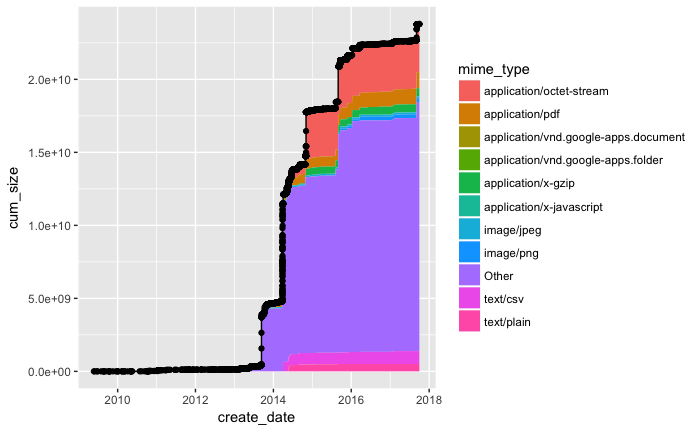

```r
plot_cum_size <- cum_types %>%
    ggplot(aes(create_date, cum_size)) +
    geom_area(aes(fill = mime_type)) +
    geom_line(data = files_cum, aes(create_date, `Cumulative File Size`, group=1)) +
    geom_point(data = files_cum, aes(create_date, `Cumulative File Size`, group=1))
plot_cum_size
```